# Practica 2 - Tipología y Ciclo de vida de datos

Para realizar dicho análisis es necesario calcular el coeficiente de correlacción de cada par de variables

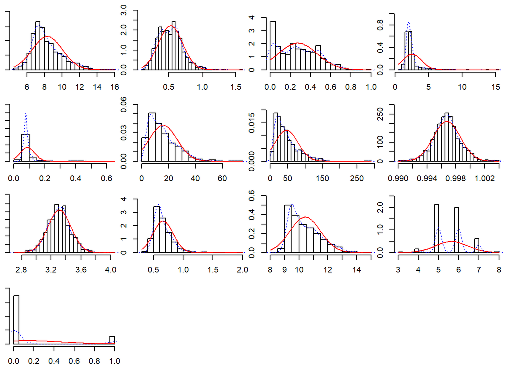

```r
multi.hist(x=redwine,dcol=c("blue", "red"),dlty = c("dotted","solid"),main="")
```

```r
round(cor(x=redwine,method = "pearson"),3)
```

```
##                      fixed.acidity volatile.acidity citric.acid residual.sugar
## fixed.acidity                1.000           -0.256       0.672          0.115
## volatile.acidity            -0.256            1.000      -0.552          0.002
## citric.acid                  0.672           -0.552       1.000          0.144
## residual.sugar               0.115            0.002       0.144          1.000
## chlorides                    0.094            0.061       0.204          0.056
## free.sulfur.dioxide         -0.154           -0.011      -0.061          0.187
## total.sulfur.dioxide        -0.113            0.076       0.036          0.203
## density                      0.668            0.022       0.365          0.355
## pH                          -0.683            0.235      -0.542         -0.086
## sulphates                    0.183           -0.261       0.313          0.006
## alcohol                     -0.062           -0.202       0.110          0.042
## quality                      0.124           -0.391       0.226          0.014
## good.wine                    0.120           -0.271       0.215          0.048
##                      chlorides free.sulfur.dioxide total.sulfur.dioxide density
## fixed.acidity            0.094              -0.154               -0.113   0.668
## volatile.acidity         0.061              -0.011                0.076   0.022
## citric.acid              0.204              -0.061                0.036   0.365
## residual.sugar           0.056               0.187                0.203   0.355
## chlorides                1.000               0.006                0.047   0.201
## free.sulfur.dioxide      0.006               1.000                0.668  -0.022
## total.sulfur.dioxide     0.047               0.668                1.000   0.071
## density                  0.201              -0.022                0.071   1.000
## pH                      -0.265               0.070               -0.066  -0.342
## sulphates                0.371               0.052                0.043   0.149
## alcohol                 -0.221              -0.069               -0.206  -0.496
## quality                 -0.129              -0.051               -0.185  -0.175
## good.wine               -0.097              -0.072               -0.140  -0.150
##                          pH sulphates alcohol quality good.wine
## fixed.acidity        -0.683     0.183  -0.062   0.124     0.120
## volatile.acidity      0.235    -0.261  -0.202  -0.391    -0.271
## citric.acid          -0.542     0.313   0.110   0.226     0.215
## residual.sugar       -0.086     0.006   0.042   0.014     0.048
## chlorides            -0.265     0.371  -0.221  -0.129    -0.097
## free.sulfur.dioxide   0.070     0.052  -0.069  -0.051    -0.072
## total.sulfur.dioxide -0.066     0.043  -0.206  -0.185    -0.140
## density              -0.342     0.149  -0.496  -0.175    -0.150
## pH                    1.000    -0.197   0.206  -0.058    -0.057
## sulphates            -0.197     1.000   0.094   0.251     0.199
## alcohol               0.206     0.094   1.000   0.476     0.407
## quality              -0.058     0.251   0.476   1.000     0.710
## good.wine            -0.057     0.199   0.407   0.710     1.000
```

- Alcohol 0.476
- Sulfatos 0.251

Comrpbamos si están relaccionadas entre ellas

```r
cor(redwine$alcohol,redwine$sulphates)
```

```
## [1] 0.09359475
```

Comprobamos que no hay colinialidad entre ambas variables **(0.09359475).**

Ahora comprobamos con un modelos de regresión lineal multiple la influencia de las variables predictoras (todas menos quality) sobre la variable dependiente (quality)

```r
calidadlm <- lm(quality  ~ .,data=redwine)
summary(calidadlm)
```

```
##
## Call:
## lm(formula = quality ~ ., data = redwine)
##
## Residuals:
##      Min       1Q   Median       3Q      Max
## -2.51156 -0.30857 -0.05853  0.41108  1.18315
##
## Coefficients:
##                        Estimate Std. Error t value Pr(>|t|)
## (Intercept)          -24.730865  16.887574  -1.464  0.14327
## fixed.acidity         -0.019823   0.020643  -0.960  0.33707
## volatile.acidity      -0.848632   0.096403  -8.803  < 2e-16 ***
## citric.acid           -0.297001   0.116847  -2.542  0.01112 *
## residual.sugar        -0.016876   0.011954  -1.412  0.15822
## chlorides             -1.010177   0.333909  -3.025  0.00252 **
## free.sulfur.dioxide    0.005090   0.001723   2.954  0.00319 **
## total.sulfur.dioxide  -0.002387   0.000579  -4.123 3.93e-05 ***
## density               30.456146  17.238997   1.767  0.07747 .
## pH                    -0.436387   0.152038  -2.870  0.00416 **
## sulphates              0.453033   0.091986   4.925 9.32e-07 ***
## alcohol                0.175803   0.021270   8.265 2.91e-16 ***
## good.wine              1.317907   0.043115  30.567  < 2e-16 ***
## ---
## Signif. codes:  0 '***' 0.001 '**' 0.01 '*' 0.05 '.' 0.1 ' ' 1
##
## Residual standard error: 0.5142 on 1586 degrees of freedom
## Multiple R-squared:  0.5976, Adjusted R-squared:  0.5946
## F-statistic: 196.3 on 12 and 1586 DF,  p-value: < 2.2e-16
```

- alcohol
- sulphates

```r
modelo<-lm(quality  ~ sulphates+alcohol,data=redwine)
summary(modelo)
```

```
##
## Call:
## lm(formula = quality ~ sulphates + alcohol, data = redwine)
##
## Residuals:
##     Min      1Q  Median      3Q     Max
## -2.6685 -0.3781 -0.1005  0.4992  2.4187
##
## Coefficients:
##             Estimate Std. Error t value Pr(>|t|)
## (Intercept)  1.37497    0.17745   7.748 1.64e-14 ***
## sulphates    0.99409    0.10235   9.713  < 2e-16 ***
## alcohol      0.34604    0.01628  21.256  < 2e-16 ***
## ---
## Signif. codes:  0 '***' 0.001 '**' 0.01 '*' 0.05 '.' 0.1 ' ' 1
##
## Residual standard error: 0.6905 on 1596 degrees of freedom
## Multiple R-squared:  0.2699, Adjusted R-squared:  0.269
## F-statistic:   295 on 2 and 1596 DF,  p-value: < 2.2e-16
```

Ahora, con un modelo más simplificado, podemos explicar el 27% de la variabilida de la calidad.

### Comprobación de la normalidad y homogeneidad de la varianza.

Realizamos un análisis de inflacción de varianza de las variables prescriptoras anteriores

```r
library(car)
vif(modelo)
```

```
## sulphates   alcohol
##  1.008837  1.008837
```

```r
sapply(redwine, ad.test)
```

```
##           fixed.acidity                     volatile.acidity
## statistic 28.14296                          5.683075
## p.value   3.7e-24                           5.318894e-14
## method    "Anderson-Darling normality test" "Anderson-Darling normality test"
## data.name "X[[i]]"                          "X[[i]]"
##           citric.acid                       residual.sugar
## statistic 17.54209                          188.0644
## p.value   3.7e-24                           3.7e-24
## method    "Anderson-Darling normality test" "Anderson-Darling normality test"
## data.name "X[[i]]"                          "X[[i]]"
##           chlorides                         free.sulfur.dioxide
## statistic 210.4492                          38.60991
## p.value   3.7e-24                           3.7e-24
## method    "Anderson-Darling normality test" "Anderson-Darling normality test"
## data.name "X[[i]]"                          "X[[i]]"
##           total.sulfur.dioxide              density
## statistic 52.48865                          3.867595
## p.value   3.7e-24                           1.227494e-09
## method    "Anderson-Darling normality test" "Anderson-Darling normality test"
## data.name "X[[i]]"                          "X[[i]]"
##           pH                                sulphates
## statistic 1.864112                          46.9322
## p.value   9.245208e-05                      3.7e-24
## method    "Anderson-Darling normality test" "Anderson-Darling normality test"
## data.name "X[[i]]"                          "X[[i]]"
##           alcohol                           quality
## statistic 34.91706                          110.6328
## p.value   3.7e-24                           3.7e-24
## method    "Anderson-Darling normality test" "Anderson-Darling normality test"
## data.name "X[[i]]"                          "X[[i]]"
##           good.wine
## statistic 489.1072
## p.value   3.7e-24
## method    "Anderson-Darling normality test"
## data.name "X[[i]]"
```

Como el valor de inflación de la varianza en inferior a 5 , no se considera colinialidad: confirmamos que son buenos predictores

El valor del P-Value es inferior a 0.05 de Alcohol y Sulfatos por lo tanto no sigue una distribución normal, es más ninguna de las columnas lo siguen

### Aplicación de pruebas estadísticas para comparar los grupos de datos.

Se ha realizado la regresión lineal de arriba

## Representación de los resultados a partir de tablas y gráficas.

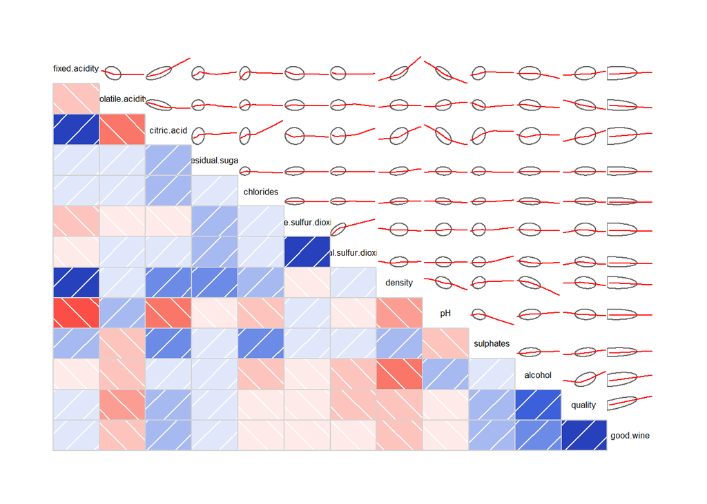

```r
corrgram(redwine, lower.panel=panel.shade, upper.panel=panel.ellipse)
```

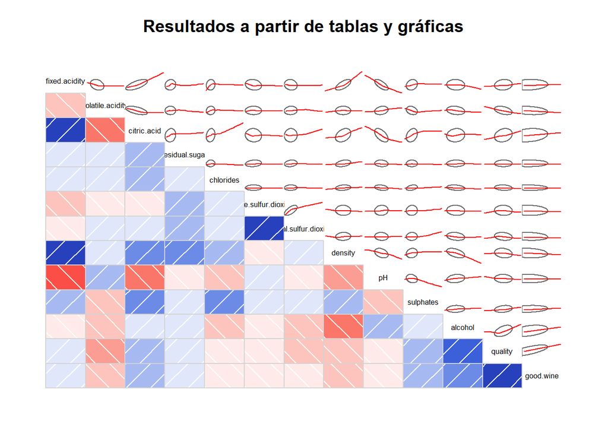

```r
corrgram(redwine, main="Resultados a partir de tablas y gráficas",lower.panel=panel.shade, upper.panel=panel.ellipse)
```

## Resolución del problema. A partir de los resultados obtenidos, ¿cuáles son las conclusiones? ¿Los resultados permiten responder al problema?

Los resultados obtenidos nos demuestran que cuanto máyor sea el valor de la variable alcohol o sulfatos, mayor será la calidad del vino